# Exercises: RMarkdown

In this practical we will introduce the basics of using RMarkdown and some of its features.

## Introduction

R Markdown is a file format for making dynamic documents with R. An R Markdown document is written in markdown (an easy-to-write plain text format) and contains *chunks* of embedded R code.

An RMarkdown document is rendered by *knitting* the file.

The `rmarkdown` package will call the `knitr` package. `knitr` will run each chunk of R code in the document and append the results of the code to the document next to the code chunk. This workflow saves time and facilitates reproducible reports.

Consider how authors typically include graphs (or tables, or numbers) in a report. The author makes the graph, saves it as a file, and then copy and pastes it into the final report. This process relies on manual labour. If the data changes, the author must repeat the entire process to update the graph.

In the R Markdown paradigm, each report contains the code it needs to make its own graphs, tables, numbers, etc. The author can automatically update the report by re-knitting.

## Creating a R Markdown document

To create an R Markdown report, open a plain text file and save it with the extension *.Rmd*. You can open a plain text file in your scripts editor by clicking *File > New File > Text File* in the RStudio tool bar, or using the *Wizard* by selecting *File > New File > R Markdown …*

#### Rendering

To go from R Markdown to pdf or html you can click on the *Knit* icon thats above the file in the scripts editor. A drop down menu will let you select the type of output that you want. RStudio will show you a preview of the new output and save the output file in your working directory. You can manually render an R Markdown file with `rmarkdown::render()`.

## Text formatting

Markdown is designed to be easy to read and easy to write. It is also very easy to learn.

Go to the drop down menu and select *Help > Markdown Quck Reference*. This will open a cheat sheet in the Help pane.

## Code chunks

Think of a chunk like a function. A chunk should be relatively self-contained, and focussed around a single task.

### Chunk options

Chunk output can be customised. A full list is here http://yihui.name/knitr/options/.

The most important set of options controls if your code block is executed and what results are inserted in the finished report:

- `eval = FALSE` prevents code from being evaluated. (And obviously if the code is not run, no results will be generated). This is useful for displaying example code, or for disabling a large block of code without commenting each line.
- `include = FALSE` runs the code, but doesn’t show the code or results in the final document. Use this for setup code that you don’t want cluttering your report.
- `echo = FALSE` prevents code, but not the results from appearing in the finished file. Use this when writing reports aimed at people who don’t want to see the underlying R code.
- `message = FALSE` or `warning = FALSE` prevents messages or warnings from appearing in the finished file.
- `results = 'hide'` hides printed output; `fig.show = 'hide'` hides plots.
- `error = TRUE` causes the render to continue even if code returns an error. This is rarely something you’ll want to include in the final version of your report, but can be very useful if you need to debug exactly what is going on inside your .Rmd. It’s also useful if you’re teaching R and want to deliberately include an error. The default, error = FALSE causes knitting to fail if there is a single error in the document.

## Tables in R Markdown

By default, R Markdown prints data frames and matrices as you’d see them in the console. If you prefer that data be displayed with additional formatting you can use the `knitr::kable` function. For even deeper customisation, consider the `xtable`, `stargazer`, `pander`, `tables`, and `ascii` packages

## Inline code

To embed R code in a line of text, surround the code with a pair of back ticks and the letter r, like this.

```r
`r  ICER is 200/0.5`
```

knitr will replace the inline code with its result in your final document (inline code is always replaced by its result). The result will appear as if it were part of the original text

## YAML header

The `output:` value determines what type of output to convert the file into when you call `rmarkdown::render()`.

`output:` recognizes the following values:

- `html_document`, which will create HTML output (default)
- `pdf_document`, which will create PDF output
- `word_document`, which will create Word output

If you use the RStudio IDE knit button to render your file, the selection you make in the gui will override the output: setting.

## Putting it all together in an example report

- Create a new R Markdown document with main sections with headings Introduction, Data, Methods, Results and Conclusions.
- Include some subheadings like Model Fitting and Recommendations, say.
- In the Conclusions make numbered list of the main findings.
- Include a link to the Briggs papers on which the original cost-effectiveness analysis is based i.e. *An Introduction to Markov Modelling for Economic Evaluation, Andrew Briggs and Mark Sculpher*
- Change the date of the document so that it will always be today’s date using the following

```r
date: "`r format(Sys.time(), '%d %B, %Y')`"
```

Pick a date format that you prefer

- Include the plot created with the following code

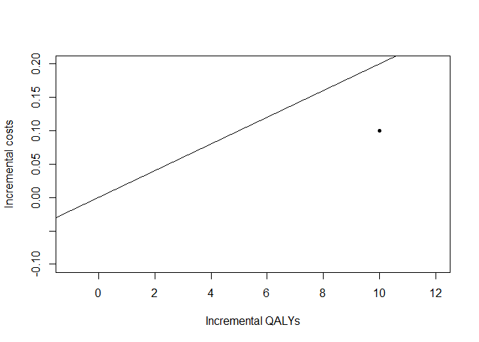

```r
plot(10, 0.1,
     xlab = "Incremental QALYs",
     ylab = "Incremental costs",
     xlim = c(-1, 12),
     ylim = c(-0.1, 0.2),
     pch = 20)
abline(a = 0, b = 0.02)
```

- Resize this plot using the chunk options
- Add a caption using `fig.cap`
- Create a table that shows the cost and QALYs for two interventions and their incremental values and ICER. Here something to start with. What do the colons do?

```r
intervention | cost | QALY | delta c | delta QALY | ICER
-------------|-----:|-----:|---------|------------|-----
```

- Now create the same table but do this programmatically. That is create a data frame with the entries and then use `knitr::kable` to convert to markdown.

Here’s an example template to get you started using `data.frame`:

```r
data.frame(intervention = c("drug a", "drug b"))|>
knitr::kable()
```

- What would be an advantage of using `tibble::tribble` here?
- Some times you just want the R code without any of the extra text. The `purl` function in the `kintr` package takes an input file, extracts the R code in it according to a list of patterns, evaluates the code and writes the output in another file. Use `purl` with your R Markdown document.
- Sometimes when a document becomes large it is easier to split it up in to smaller document and then combine these in a top level file. This is possible in R Markdown using *children* chunks. Simply use the argument `child` assigned to the name of the `Rmd` file and this will be inserted in to the document in place of this chunk.

`{r child = "mychilddoc.Rmd"}`

Create a Methods block and a Results child chunk for your current document.